# HSC Survey Results

# German Bank Survey # 4 Results from 20/09/2026

## Survey Details

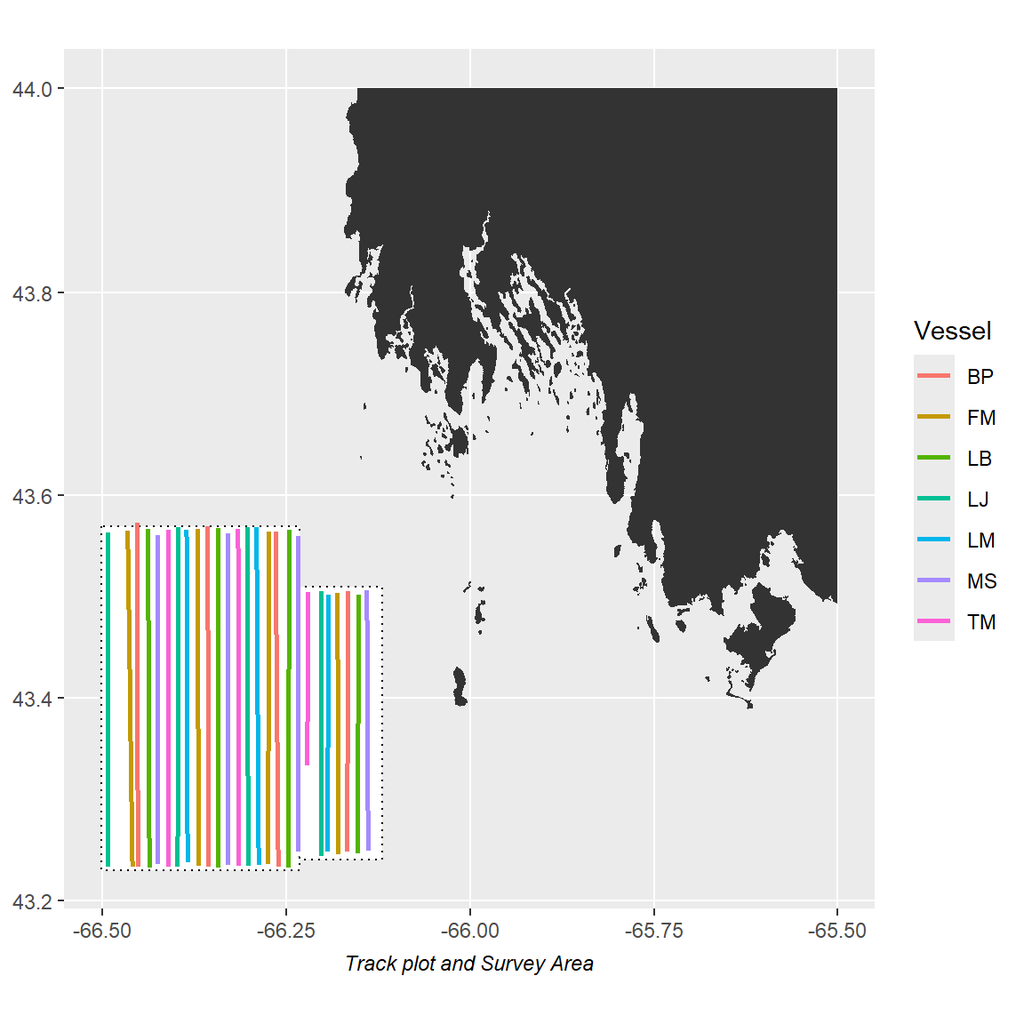

There was a plankton tow and replicate conducted and CTD cast by Tasha Marie.

No tags were applied during this survey.

Samples were obtained for target strength estimation.

### Acoustic Equipment

Each vessel was equipped with a Simrad ES38-18/200-18C combi (2-in-1) transducer prior to the survey that contains a 38kHz split beam and 200 kHz single beam transducer. Data was logged to the computer hard-drive for post-processing. All participating boats were calibrated on 38kHz before the survey.

## Survey Results

### Main Results

The results are subject to change as DFO will re-evaluate data editing, area estimation and apply a target strength.

**Preliminary biomass prediction for German Bank using standardized parallel transects is 26,876mt, and with turnover applied 19,231mt. The preliminary biomass estimate for Seal Island is 11,583mt.**

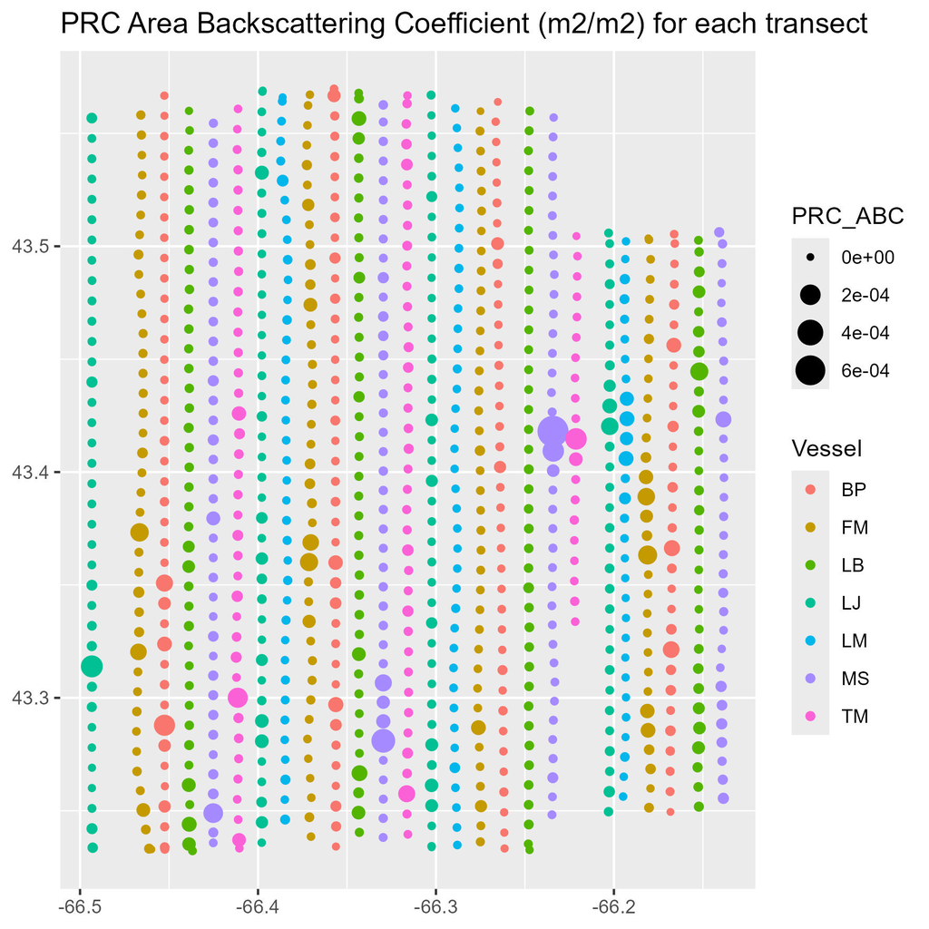

### Transect Details

Table 1: Transect Details

| Vessel | Transect # | Date/Time Start | Date/Time End | Start Lon | Start Lat | End Lon | End Lat | Location | Distance (km) | Speed |
| --- | --- | --- | --- | --- | --- | --- | --- | --- | --- | --- |
| BP | T01 | 2026-09-20 18:50:26 | 2026-09-20 21:24:55 | -66.454 | 43.573 | -66.452 | 43.233 | GB | 37.83 | 7.93 |
| BP | T02 | 2026-09-20 21:47:00 | 2026-09-21 00:06:34 | -66.357 | 43.234 | -66.357 | 43.570 | GB | 37.41 | 8.68 |
| BP | T03 | 2026-09-21 00:29:45 | 2026-09-21 02:48:10 | -66.265 | 43.564 | -66.261 | 43.233 | GB | 36.80 | 8.61 |
| BP | T04 | 2026-09-21 03:18:49 | 2026-09-21 05:05:43 | -66.168 | 43.248 | -66.166 | 43.505 | GB | 28.65 | 8.68 |
| FM | T01 | 2026-09-20 20:19:20 | 2026-09-20 22:43:16 | -66.466 | 43.566 | -66.460 | 43.233 | GB | 37.95 | 8.54 |
| FM | T02 | 2026-09-20 23:04:18 | 2026-09-21 01:29:25 | -66.370 | 43.234 | -66.371 | 43.567 | GB | 38.10 | 8.51 |
| FM | T03 | 2026-09-21 01:53:58 | 2026-09-21 04:14:15 | -66.275 | 43.565 | -66.275 | 43.236 | GB | 37.37 | 8.63 |
| FM | T04 | 2026-09-21 04:49:21 | 2026-09-21 06:41:43 | -66.180 | 43.245 | -66.181 | 43.504 | GB | 29.79 | 8.59 |
| LB | T01 | 2026-09-20 18:51:59 | 2026-09-20 21:24:02 | -66.439 | 43.567 | -66.437 | 43.232 | GB | 38.24 | 8.15 |
| LB | T02 | 2026-09-20 21:49:04 | 2026-09-21 00:15:53 | -66.344 | 43.232 | -66.343 | 43.568 | GB | 38.25 | 8.44 |
| LB | T03 | 2026-09-21 00:44:13 | 2026-09-21 03:07:16 | -66.247 | 43.566 | -66.247 | 43.233 | GB | 38.02 | 8.61 |
| LB | T04 | 2026-09-21 03:40:07 | 2026-09-21 05:25:59 | -66.153 | 43.247 | -66.153 | 43.503 | GB | 29.30 | 8.97 |
| LJ | T01 | 2026-09-20 19:30:58 | 2026-09-20 21:54:49 | -66.494 | 43.564 | -66.493 | 43.234 | GB | 36.70 | 8.26 |
| LJ | T02 | 2026-09-20 22:17:52 | 2026-09-21 00:45:33 | -66.398 | 43.233 | -66.397 | 43.569 | GB | 37.36 | 8.19 |
| LJ | T03 | 2026-09-21 01:10:28 | 2026-09-21 03:34:50 | -66.304 | 43.569 | -66.302 | 43.234 | GB | 37.31 | 8.37 |
| LJ | T04 | 2026-09-21 04:04:00 | 2026-09-21 05:51:49 | -66.203 | 43.244 | -66.203 | 43.506 | GB | 29.15 | 8.76 |
| LM | T02 | 2026-09-20 22:13:55 | 2026-09-21 00:38:04 | -66.385 | 43.237 | -66.386 | 43.566 | GB | 37.19 | 8.36 |
| LM | T03 | 2026-09-21 01:02:29 | 2026-09-21 03:27:27 | -66.291 | 43.569 | -66.288 | 43.235 | GB | 37.81 | 8.45 |
| LM | T04 | 2026-09-21 03:55:55 | 2026-09-21 05:49:09 | -66.194 | 43.249 | -66.193 | 43.502 | GB | 28.78 | 8.23 |
| MS | T01 | 2026-09-20 20:25:47 | 2026-09-20 22:42:45 | -66.425 | 43.561 | -66.425 | 43.236 | GB | 37.24 | 8.81 |
| MS | T02 | 2026-09-20 23:08:11 | 2026-09-21 01:27:44 | -66.329 | 43.235 | -66.330 | 43.563 | GB | 38.29 | 8.89 |
| MS | T03 | 2026-09-21 01:56:24 | 2026-09-21 04:12:25 | -66.235 | 43.560 | -66.235 | 43.248 | GB | 36.29 | 8.64 |
| MS | T04 | 2026-09-21 04:45:47 | 2026-09-21 06:32:20 | -66.139 | 43.249 | -66.141 | 43.506 | GB | 30.46 | 9.26 |
| TM | T01 | 2026-09-20 19:28:29 | 2026-09-20 21:50:40 | -66.410 | 43.566 | -66.410 | 43.233 | GB | 37.05 | 8.44 |
| TM | T02 | 2026-09-20 22:16:02 | 2026-09-21 00:32:58 | -66.315 | 43.234 | -66.316 | 43.567 | GB | 37.04 | 8.76 |
| TM | T03 | 2026-09-21 01:07:23 | 2026-09-21 02:20:46 | -66.221 | 43.505 | -66.222 | 43.334 | GB | 19.05 | 8.41 |

### Survey Summary

Table 2: Acoustic Survey Results

| Vessel | Transect No. | Target Strength (db/kg) | Mean Sa (/m2) | Biomass Density (kg/m2) |
| --- | --- | --- | --- | --- |
| MS | T03 | -35.5 | -45.523 | 0.099 |
| FM | T04 | -35.5 | -47.290 | 0.066 |
| MS | T02 | -35.5 | -47.855 | 0.058 |
| TM | T03 | -35.5 | -48.076 | 0.055 |
| LB | T04 | -35.5 | -48.548 | 0.050 |
| BP | T01 | -35.5 | -48.941 | 0.045 |
| BP | T04 | -35.5 | -49.147 | 0.043 |
| FM | T02 | -35.5 | -49.411 | 0.041 |
| TM | T01 | -35.5 | -49.516 | 0.040 |
| MS | T01 | -35.5 | -49.626 | 0.039 |
| FM | T01 | -35.5 | -49.927 | 0.036 |
| LJ | T04 | -35.5 | -49.971 | 0.036 |
| LJ | T01 | -35.5 | -50.035 | 0.035 |
| LB | T02 | -35.5 | -50.056 | 0.035 |
| LM | T04 | -35.5 | -50.119 | 0.035 |
| BP | T02 | -35.5 | -50.825 | 0.029 |
| LB | T01 | -35.5 | -51.033 | 0.028 |
| LJ | T02 | -35.5 | -51.112 | 0.027 |
| TM | T02 | -35.5 | -51.278 | 0.026 |
| MS | T04 | -35.5 | -51.592 | 0.025 |
| LJ | T03 | -35.5 | -52.282 | 0.021 |
| FM | T03 | -35.5 | -54.279 | 0.013 |
| LB | T03 | -35.5 | -54.816 | 0.012 |
| BP | T03 | -35.5 | -55.650 | 0.010 |
| LM | T02 | -35.5 | -56.393 | 0.008 |
| LM | T03 | -35.5 | -58.727 | 0.005 |

Note:  
Transects are listed from greatest to least backscatter.

Table 3: Survey Summary Table

| Layer | Target Strength | Area (km2) | Mean Sa | Density (kg/m2) | Biomass (tons) | Percent Area | Percent Biomass | Standard Error (tons) | Standard Error (%) |
| --- | --- | --- | --- | --- | --- | --- | --- | --- | --- |
| German Bank | -35.5 | 826 | -50.3762 | 0.0332 | 26,875.65 | 75.1 | 69.9 | 3,999.69 | 14.88 |
| Seal Island | -35.5 | 274 | -49.2392 | 0.0423 | 11,583.20 | 24.9 | 30.1 | 1,615.60 | 13.95 |

### Greatest Biomass Densities

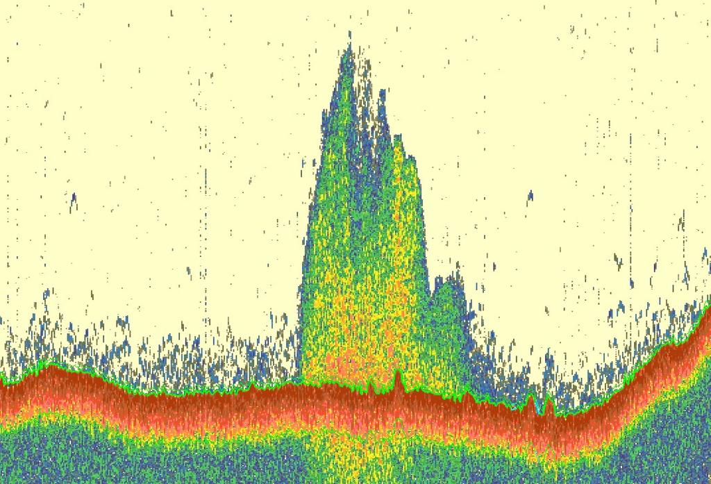

A snip from the transect with the greatest biomass density (kg/m2)

The single point with the largest biomass density (kg/m2) was recorded by **MS**, at the following location:

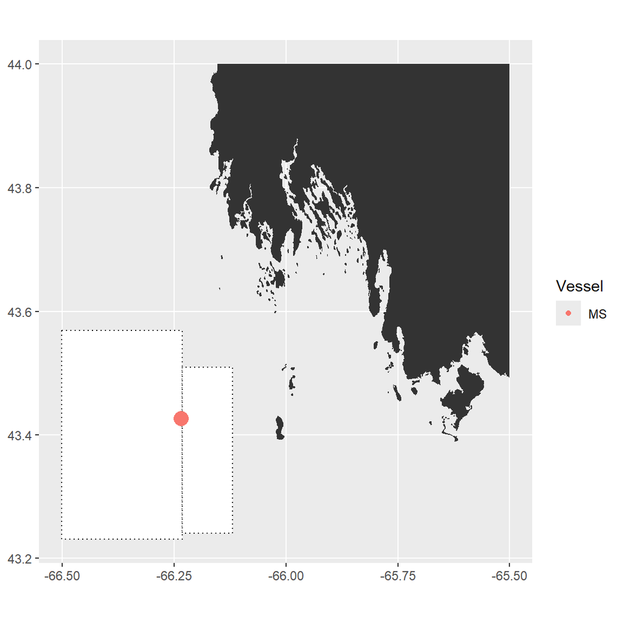

The transect with the greatest average biomass density (kg/m2) was recorded by **MS**, at the following location:

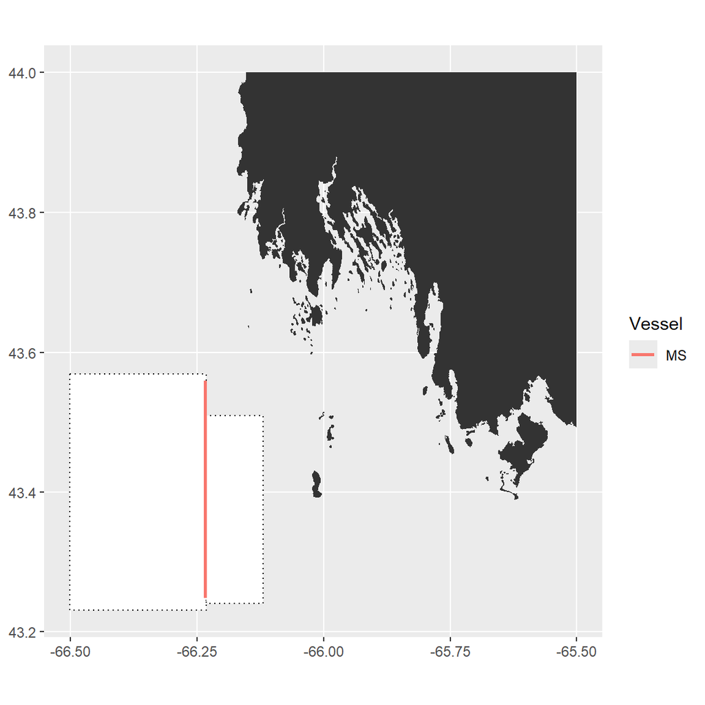

### Annual Summaries

This table does not include the biomass from adhoc surveys.

Table 4: Annual Comparison Table

| Ground | Survey Number | Current Year Survey Date | Current Year HSC Estimate | Current Year HSC Turnover Adjusted | Previous Year Survey Date | Previous Year HSC Estimate | Previous Year HSC Turnover Adjusted | Previous Year DFO Estimate | Previous Year DFO Turnover Adjusted |
| --- | --- | --- | --- | --- | --- | --- | --- | --- | --- |
| German Bank | 1 | 2026-08-09 | 51,965.016 | 51,965.02 | 2025-08-04 | 6,194 | 6,194 | 12,322 | 12,322 |
| Seal Island | 1 | 2026-08-09 | 7,023.005 | NA | 2025-08-04 | 1,160 | NA | NA | NA |
| German Bank | 2 | 2026-08-24 | 23,001.855 | 19,220.00 | 2025-08-18 | 35,008 | 32,592 | 28,929 | 26,847 |
| Seal Island | 2 | 2026-08-24 | 4,584.286 | NA | 2025-08-18 | 6,220 | NA | NA | NA |
| German Bank | 3 | 2026-09-06 | 34,030.898 | 28,409.00 | 2025-08-31 | 30,892 | 21,986 | 37,085 | 31,244 |
| Seal Island | 3 | 2026-09-06 | 7,502.870 | NA | 2025-08-31 | 6,500 | NA | NA | NA |
| German Bank | 4 | 2026-09-20 | 26,875.651 | 19,231.00 | 2025-09-14 | 15,323 | 7,753 | 39,480 | 32,402 |
| Seal Island | 4 | 2026-09-20 | 11,583.204 | NA | 2025-09-14 | 18,112 | NA | NA | NA |
| German Bank | 5 | NA | NA | NA | 2025-09-28 | 6,754 | 2,138 | 13,730 | 6,131 |
| Seal Island | 5 | NA | NA | NA | 2025-09-28 | 5,048 | NA | NA | NA |
| German Bank | 6 | NA | NA | NA | 2025-10-14 | 8,611 | 7,291 | 19,699 | 17,018 |
| Seal Island | 6 | NA | NA | NA | 2025-10-14 | 10,346 | NA | NA | NA |
| German Bank | 7 | NA | NA | NA | 2025-10-26 | 20,039 | 17,877 | 27,192 | 22,810 |
| Seal Island | 7 | NA | NA | NA | 2025-10-26 | 3,433 | NA | NA | NA |

Table 5: Annual Summary Table

| Year | Ground | HSC Estimate | HSC Turnover Adjusted | DFO Estimate | DFO Turnover Adjusted |
| --- | --- | --- | --- | --- | --- |
| 2025 | German Bank | 122,821.00 | 95,831 | 178,437 | 148,774 |
| 2025 | Seal Island | 50,819.00 | NA | NA | NA |
| 2026 | German Bank | 135,873.42 | 118,825 | NA | NA |
| 2026 | Seal Island | 30,693.36 | NA | NA | NA |

## Plankton and CTD Data

### Plankton Data

#### Tow Summary Table

|  | Tow 1 | Tow 2 |
| --- | --- | --- |
| **Base Details** |  |  |
| Vessel | Tasha Marie | Tasha Marie |
| Set Number | GB2026-07 | GB2026-08 |
| Ground | GB | GB |
| Date | 20/09/2026 | 20/09/2026 |
| Wind Direction (km/h) | SE | SE |
| Swell (m) | 0 | 0 |
| Air Temp (c) | 14 | 14 |
| **Tow Details** |  |  |
| Tow Start | 18:36:00 | 18:55:00 |
| Tow End | 18:46:00 | 19:05:00 |
| Start Lat | 43.57033 | 43.56283 |
| End Lat | 43.56500 | 43.56883 |
| Start Lon | -66.36017 | -66.35467 |
| End Lon | -66.3625 | -66.3635 |
| Avg Tow Depth (m) | 1.794162 | 1.299796 |
| Speed | 1.6 | 3.4 |
| Heading | 220 | 326 |
| Tide Direction | against | with |
| **Other Data Collection** |  |  |
| Flow Start | 326321 | 358115 |
| Flow End | 358115 | 389670 |
| No. Revolutions | 31794 | 31555 |
| Distance (m) | 854.4002 | 847.9775 |
| Volume | 2684.098 | 2663.921 |
| Secchi Disappear (m) | 13 | 13 |
| Secchi Reappear (m) | 13 | 13 |

#### Tow Depth Profiles

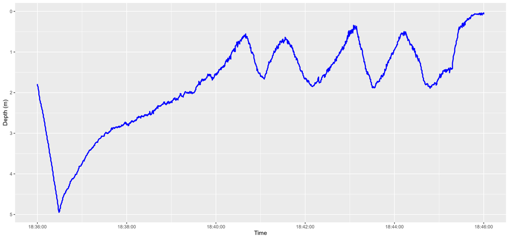

Plankton tow depth profile #1

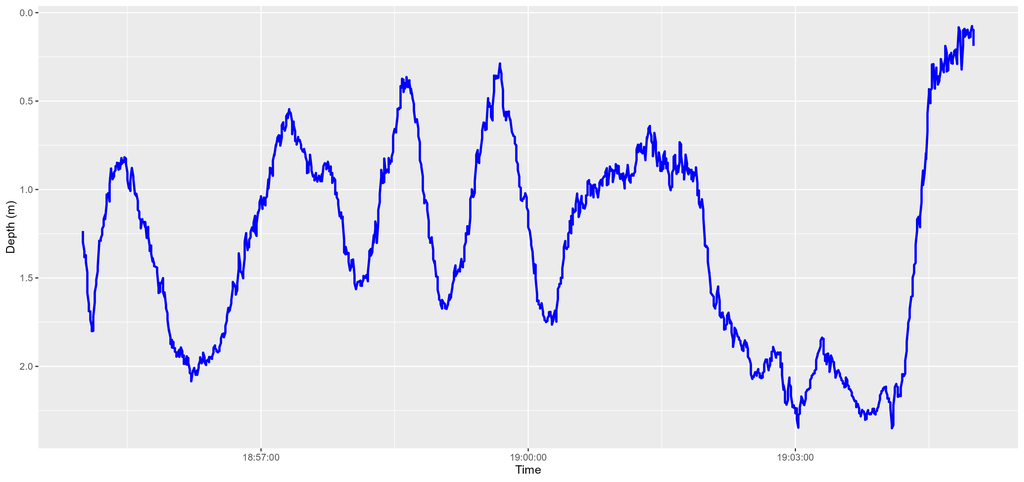

Plankton tow depth profile #2

The first tow is GB2026-07, which was against the tide and had an average depth of 1.7941624m. The second tow is GB2026-08, which was with the tide and had an average depth of 1.2997959m.

#### Captured plankton

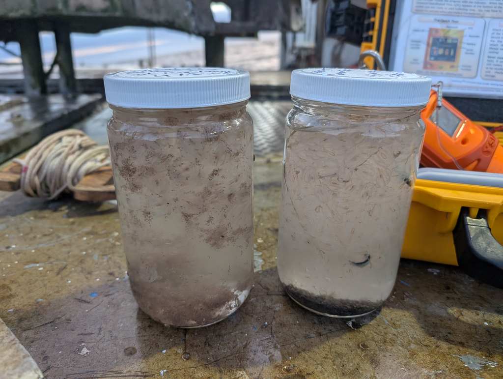

Captured plankton from the surface tows

### CTD Data

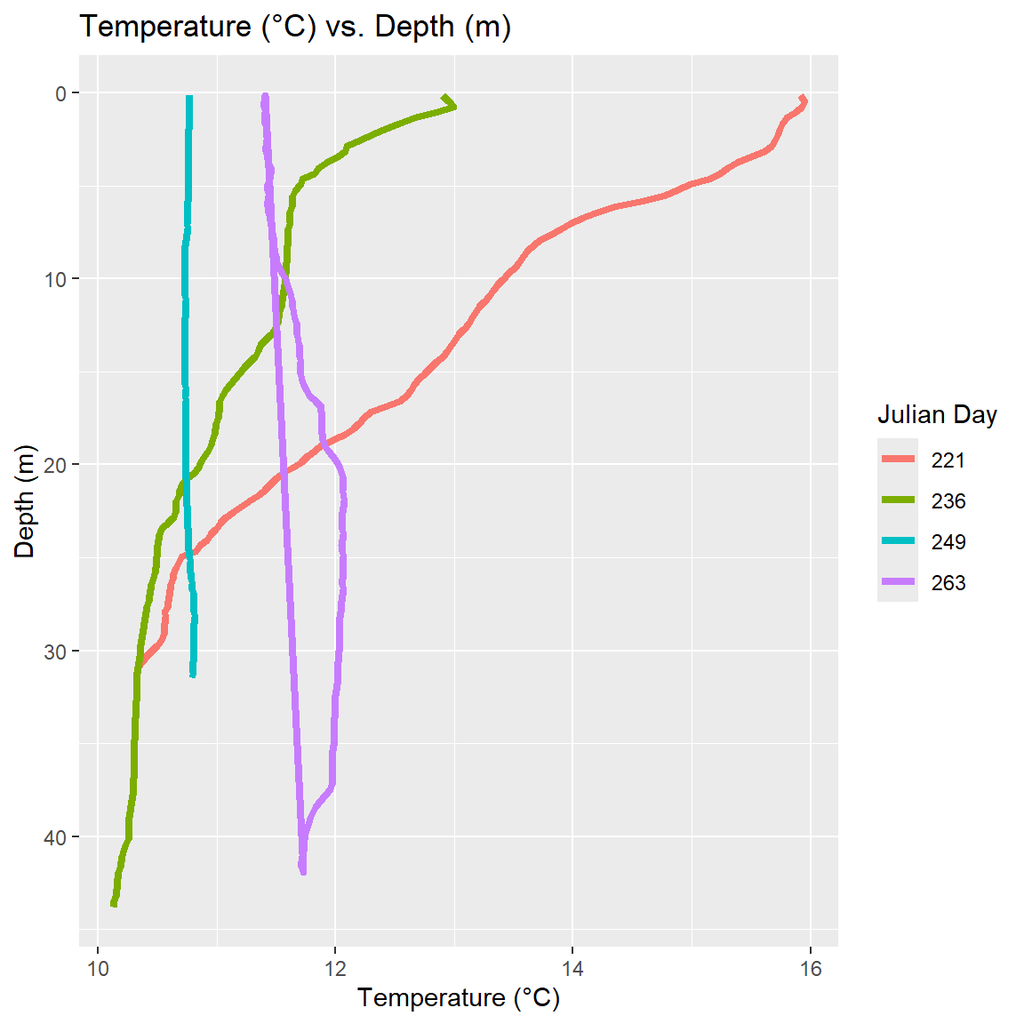

CTD depth profiles for all 2026 German Bank surveys so far.

#### Sea surface temperatures

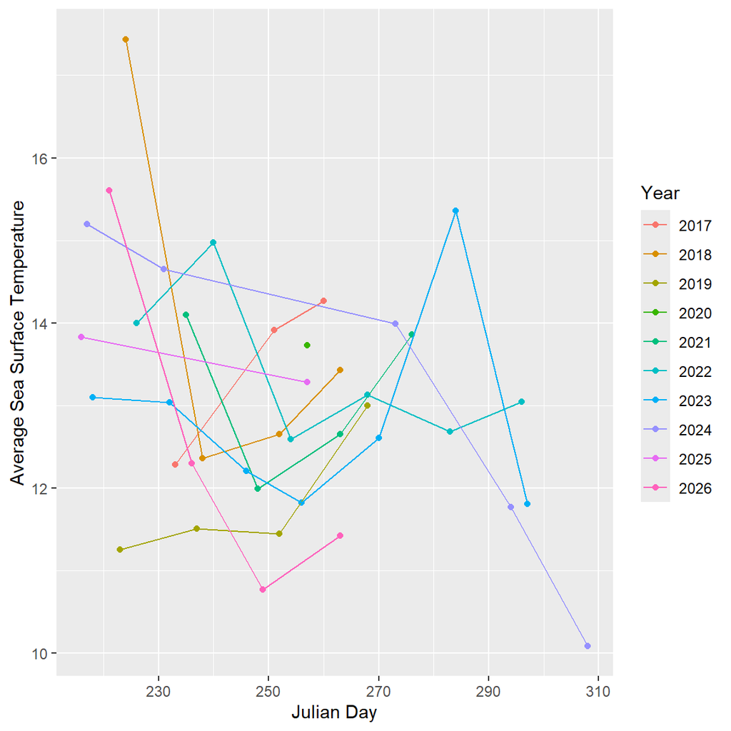

Annual average sea surface temperatures (SST) for German Bank.

## Vessel Performance

### Speed

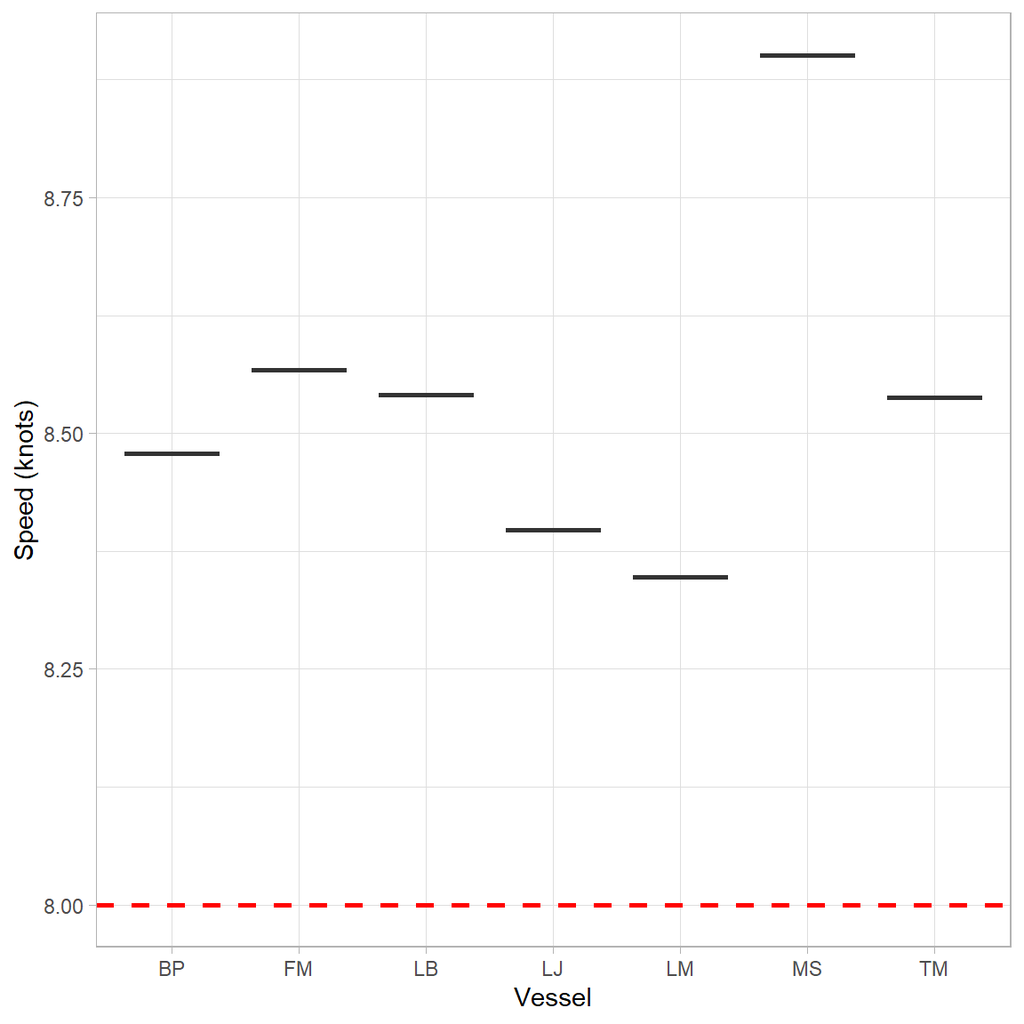

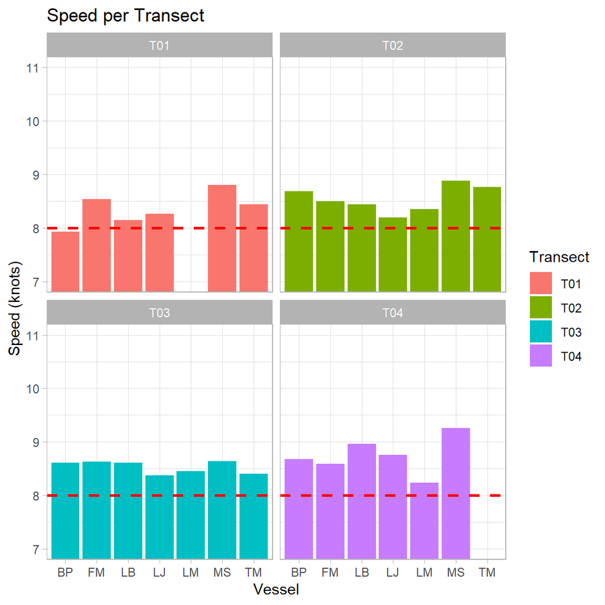

Average vessel speed was 8.54. This is above the 8 knot requirement; vessels are urged to slow down to prevent backscatter noise from interfering with the acoustic data.

The speed for each transect are rudimentary and are calculated based on distance. If a significant amount of distance is cut, the speed will appear slower.

### Distance

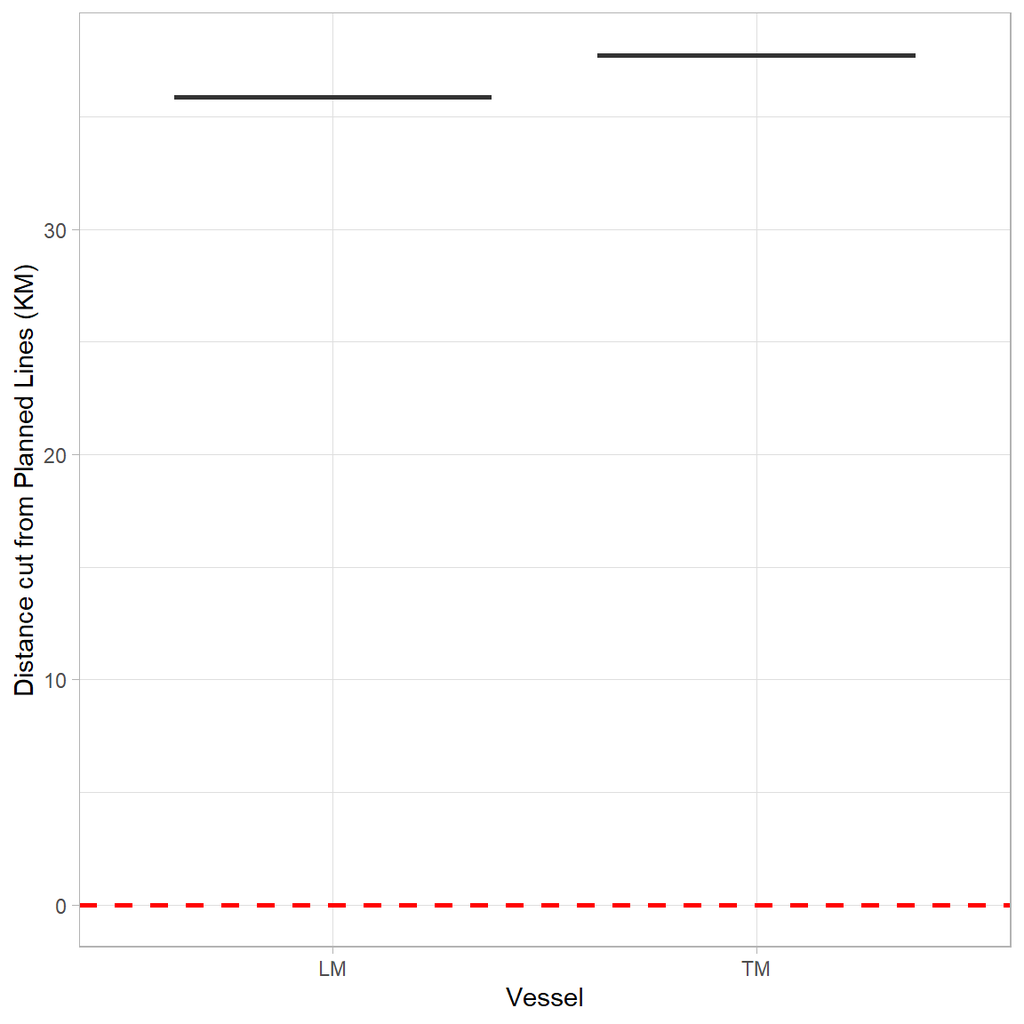

More than 2km of distance was cut from the planned lines; vessels are reminded to complete their assigned lines straight and without deviating or cutting corners short.